# Beliefs and behaviors about COVID-19 in Uganda’s capital

A survey in Kampala, Uganda

## Team

We are a team including experts in the fields of economics, health, and political science. Our team has experience conducting research across sub-Saharan Africa, and over 15 years of research experience in Uganda specifically. The survey is implemented by Innovations for Poverty Action (IPA) Uganda. This survey on COVID-19 builds on an existing project in collaboration with the Kampala Capital City Authority (KCCA). Our team members are listed below:

**PIs:**

- Manuel Bosancianu, research fellow, WZB Berlin Social Science Center
- Ana Garcia-Hernandez, research fellow, WZB Berlin Social Science Center
- Macartan Humphreys, Professor of Political Science, Columbia University and WZB Berlin
- Paul Kiwanuka-Mukiibi, PS Consulting, Uganda
- Melina Platas, Assistant Professor of Political Science, NYU Abu Dhabi
- Leah Rosenzweig, Postdoctoral Fellow, Stanford University
- Lily Tsai, Ford Professor of Political Science, Massachusetts Institute of Technology

**Research staff:**

- Anthony Kamwesigye, Innovations for Poverty Action
- Diana Zhu, PhD Student, Massachusetts Institute of Technology
- Elly Atuhumuza, Innovations for Poverty Action
- Julian Cantor, WZB Berlin Social Science Center
- Julio Solís, WZB Berlin Social Science Center
- Martin Atyera, Innovations for Poverty Action
- Rodrigo Cordova Ponce, Massachusetts Institute of Technology
- Sisi Huang, WZB Berlin Social Science Center

**Survey team:**

- Adede Deborah
- Amanya Joshua
- Amara Andrew
- Atukwatse Naome
- Bakashaba Kenneth
- Esther K
- Grace Nabitaka
- Kabarungi Sophie
- Kembabazi Allen
- Louis Joseph
- Mayanja Patrick
- Mukunzi Ivan
- Musa Muzei
- Naigaga Sophia
- Naluwooza Flavia Byaruhanga
- Namagembe Angella
- Namboowa Betty
- Namuganga Sylvia
- Ssenyonjo Julius

## How To

This dashboard presents results from the most recent surveys available. Click on each section to see results. The “Aggregates” tab presents results graphically, the “Current averages” tab shows the average value for each indicator, and the “Definitions of measures” tab shows the exact question wording and answer categories.

To download data or search for an indicator, select the “All data” tab. Data can be downloaded as a csv or Excel file.

For comments or questions on the dashboard, please email Julio Solís at julio.solis@wzb.eu.

## Policy evaluation

### Aggregates

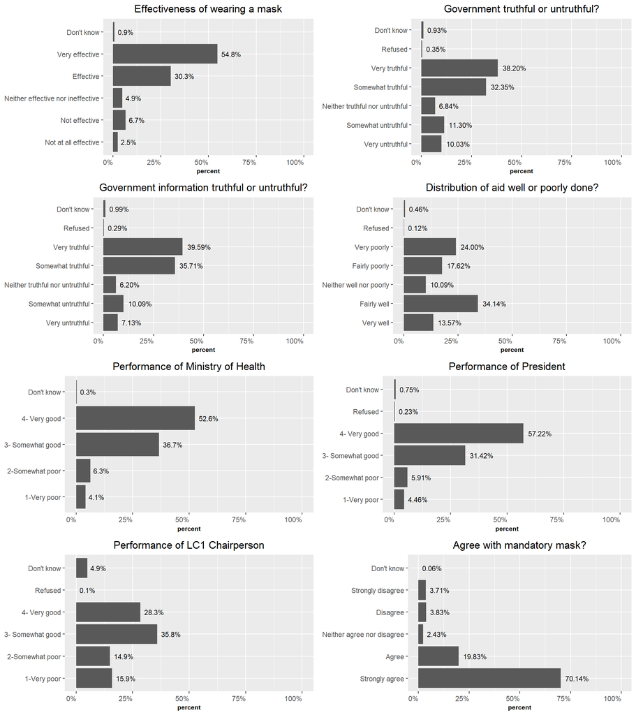

### Current averages

Mean responses in each Group (most recent date)

| Group | Date | Effectiveness of wearing a mask | Government truthful or untruthful? | Government information truthful or untruthful? | Distribution of aid well or poorly done? | Performance of Ministry of Health | Performance of President | Performance of LC1 Chairperson | Agree with mandatory mask? |
| --- | --- | --- | --- | --- | --- | --- | --- | --- | --- |
| Kampala | 2020-07-19 | 12.94 | 15.7 | 15.96 | 8.56 | 6.85 | 12.72 | 52.34 | 2.09 |

### Maps

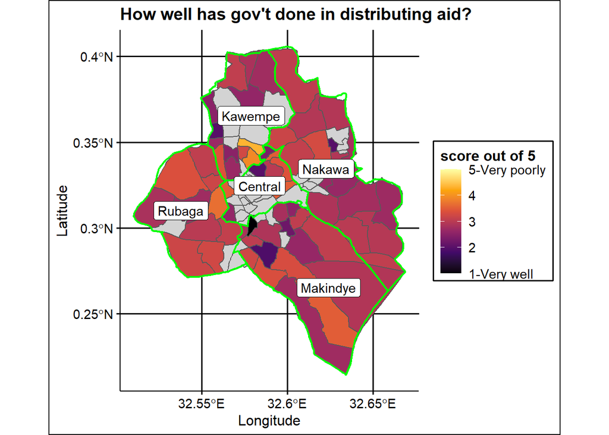

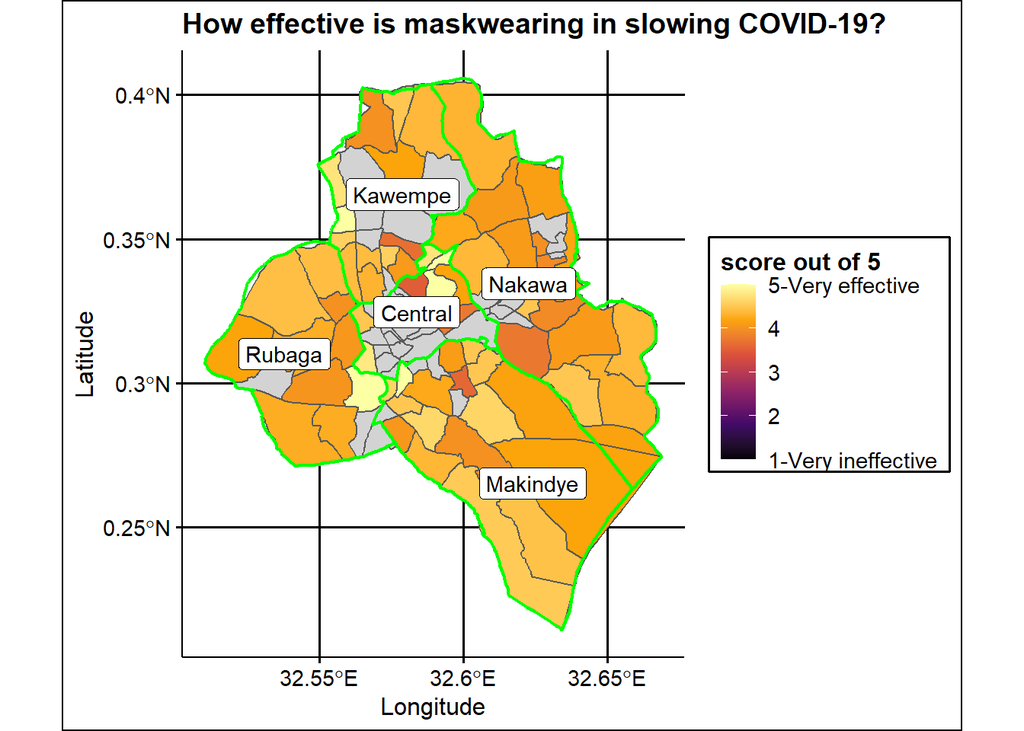

### Definitions of measures

Data definitions

| Measure | Definition |
| --- | --- |
| Effectiveness of wearing a mask | How effective do you think wearing a mask is for slowing down the spread of the coronavirus? |
| Government truthful or untruthful? | How truthful or untruthful do you think the Ugandan government has been about the coronavirus outbreak? |
| Government information truthful or untruthful? | How truthful or untruthful do you think the Ugandan government has been with information about the coronavirus outbreak? |
| Distribution of aid well or poorly done? | How well or poorly do you think the Ugandan government has performed in distributing aid to those who need it? |
| Performance of Ministry of Health | On a scale of 1 to 4, where 1 means “very poor” and 4 means “very good”, how would you rate the performance of each of the following in handling COVID in Uganda? Ministry of Health |
| Performance of President | On a scale of 1 to 4, where 1 means “very poor” and 4 means “very good”, how would you rate the performance of each of the following in handling COVID in Uganda? The President |
| Performance of LC1 Chairperson | On a scale of 1 to 4, where 1 means “very poor” and 4 means “very good”, how would you rate the performance of each of the following in handling COVID in Uganda? Your LC1 chairperson |
| Agree with mandatory mask? | To what extent do you agree or disagree with a policy of mandatory mask wearing when leaving home? |

## Psychological well-being

### Aggregates

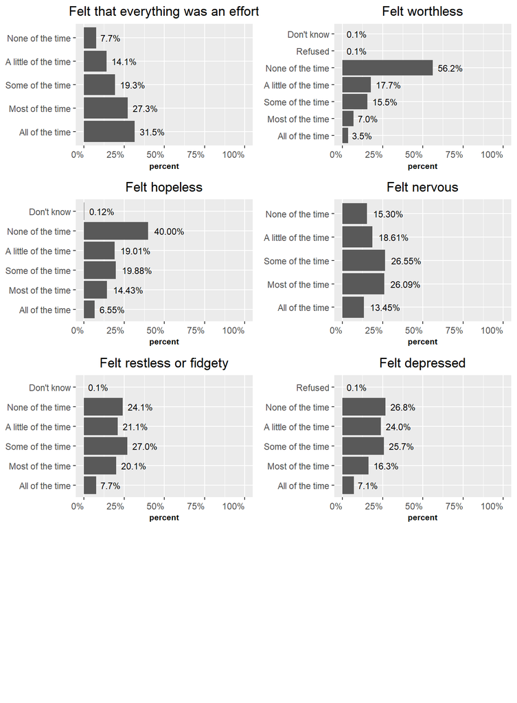

### Current averages

Mean responses in each Group (most recent date)

| Group | Date | Felt that everything was an effort | Felt worthless | Felt hopeless | Felt nervous | Felt restless or fidgety | Felt depressed |
| --- | --- | --- | --- | --- | --- | --- | --- |
| Kampala | 2020-07-19 | 2.39 | 5.19 | 4.87 | 2.96 | 3.92 | 3.92 |

### Definitions of measures

Data definitions

| Measure | Definition |
| --- | --- |
| Felt that everything was an effort | During the past 30 days, about how often did you feel… that everything was an effort? |
| Felt worthless | During the past 30 days, about how often did you feel… worthless? |
| Felt hopeless | During the past 30 days, about how often did you feel… hopeless? |
| Felt nervous | During the past 30 days, about how often did you feel… nervous? |
| Felt restless or fidgety | During the past 30 days, about how often did you feel… restless or fidgety?? |
| Felt depressed | During the past 30 days, about how often did you feel… so depressed that nothing could cheer you up? |

## Knowledge about disease

### Aggregates

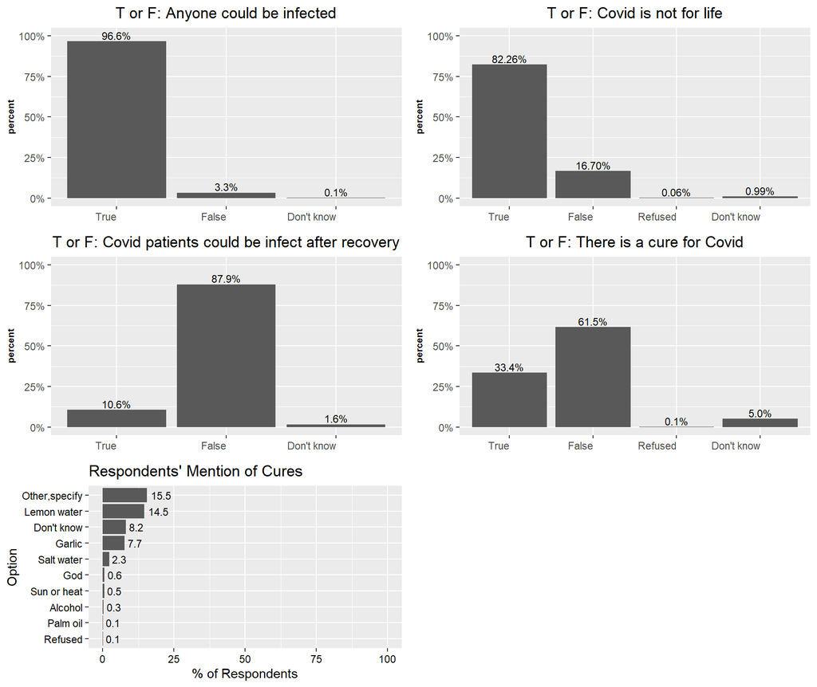

### Current averages

Mean responses in each Group (most recent date)

| Group | Date | T or F: Anyone could be infected | T or F: Covid is not for life | T or F: Covid patients could be infect after recovery | T or F: There is a cure for Covid |
| --- | --- | --- | --- | --- | --- |
| Kampala | 2020-07-19 | 1.61 | 11.45 | 17.5 | 52.4 |

### Definitions of measures

Data definitions

| Measure | Definition |
| --- | --- |
| T or F: Anyone could be infected | True or False: Anyone can be infected by Coronavirus. |
| T or F: Covid is not for life | True or False: Catching the new coronavirus DOES NOT mean you will have it for life. |
| T or F: Covid patients could be infect after recovery | True or False: If someone falls ill with COVID-19 and then recovers, they can still infect others in the future. |
| T or F: There is a cure for Covid | True or False: There is a cure for Coronavirus. |

## Economic situation

### Aggregates

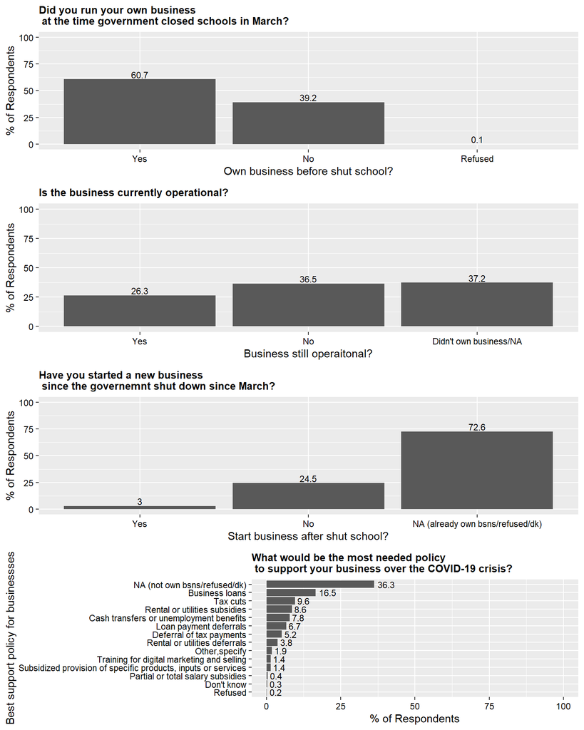

### Current averages

Mean responses in each Group (most recent date)

| Group | Date | Do you own your own business? | Is you business currently operational? | Have you started a new business since government closed schools? | What would be the most needed policy to support your business? |
| --- | --- | --- | --- | --- | --- |
| Kampala | 2020-07-19 | 1.84 | 1.58 | 1.89 | 37.06 |

### Definitions of measures

Data definitions

| Measure | Definition |
| --- | --- |
| Do you own your own business? | Do you own your own business? |
| Is you business currently operational? | Is the business currently operational? |
| Have you started a new business since government closed schools? | Have you opened a new business? |
| What would be the most needed policy to support your business? | Most preferred policy to support business |

## Employment

### Aggregates

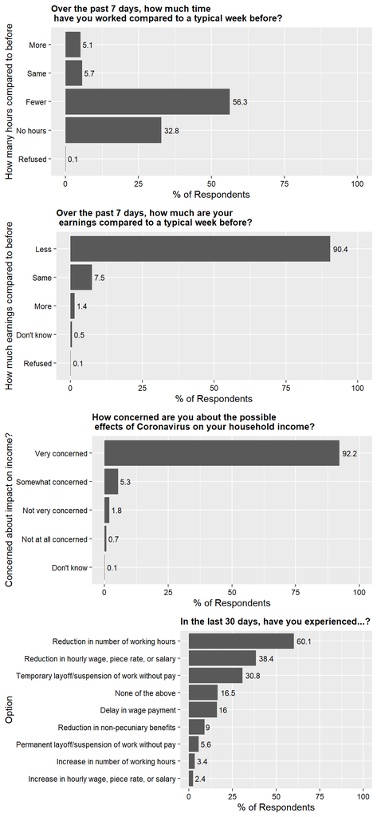

### Current averages

Mean responses in each Group (most recent date)

| Group | Date | In the past 7 days, did you spend more, the same, fewer or no hours (working for pay/ running a business/ helping on a family business) than you did in a typical week before government closed the scho… | During the past 7 days, did you earn more, the same, or less pay than you did in a typical week before government closed the schools? | How concerned are you about the possible effects of coronavirus on your household livelihood /income? | Temporary layed off | Permanently layed off | Reduced number of working hours | Increased number of working hours | Reduction in hourly wage, piece rate, or salary | Increased hourly wage, piece rate, or salary | Delayed payment | Reduced non-pecuniary benefits | None of the above |
| --- | --- | --- | --- | --- | --- | --- | --- | --- | --- | --- | --- | --- | --- |
| Kampala | 2020-07-19 | 3.62 | 8.99 | 4.47 | 0.31 | 0.06 | 0.6 | 0.03 | 0.38 | 0.02 | 0.16 | 0.09 | 0.17 |

### Definitions of measures

Data definitions

| Measure | Definition |
| --- | --- |
| In the past 7 days, did you spend more, the same, fewer or no hours (working for pay/ running a business/ helping on a family business) than you did in a typical week before government closed the scho… | Time working relative to pre-Covid |
| During the past 7 days, did you earn more, the same, or less pay than you did in a typical week before government closed the schools? | Earnings relative to pre-Covid |
| How concerned are you about the possible effects of coronavirus on your household livelihood /income? | Concerned about Covid affecting income |
| Temporary layed off | In the last 30 days, have you experienced any of the following because of COVID-19 / coronavirus or related restrictions? Temporary layoff/suspension of work (without pay) |
| Permanently layed off | In the last 30 days, have you experienced any of the following because of COVID-19 / coronavirus or related restrictions? Permanent layoff/suspension of work (without pay) |
| Reduced number of working hours | In the last 30 days, have you experienced any of the following because of COVID-19 / coronavirus or related restrictions? Reduction in number of working hours |
| Increased number of working hours | In the last 30 days, have you experienced any of the following because of COVID-19 / coronavirus or related restrictions? Increase in number of working hours |
| Reduction in hourly wage, piece rate, or salary | In the last 30 days, have you experienced any of the following because of COVID-19 / coronavirus or related restrictions? Reduction in hourly wage, piece rate, or salary |
| Increased hourly wage, piece rate, or salary | In the last 30 days, have you experienced any of the following because of COVID-19 / coronavirus or related restrictions? Increase in hourly wage, piece rate, or salary |
| Delayed payment | In the last 30 days, have you experienced any of the following because of COVID-19 / coronavirus or related restrictions? Delay in wage payment |
| Reduced non-pecuniary benefits | In the last 30 days, have you experienced any of the following because of COVID-19 / coronavirus or related restrictions? Reduction in non-pecuniary benefits, such as employer-provided childcare, empl… |
| None of the above | In the last 30 days, have you experienced any of the following because of COVID-19 / coronavirus or related restrictions? None of the above |

## Food security

### Aggregates

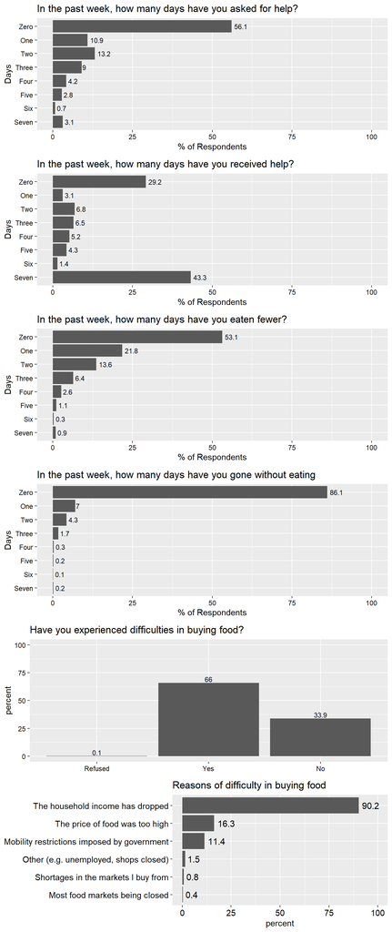

### Current averages

Mean responses in each Group (most recent date)

| Group | Date | Asked for help from family or friends | Eaten less than usual per day than normal | Received help from family or friends | Spent the whole day without eating | Difficulties buying food | Due to mobility restrictions | Due to markets closed | Due to shortages in martkets | Due to high price | Due to low income | Other (e.g. unemployed, shops closed) |
| --- | --- | --- | --- | --- | --- | --- | --- | --- | --- | --- | --- | --- |
| Kampala | 2020-07-19 | 2.37 | 5.25 | 2.53 | 1.15 | 2.24 | 0.11 | 0 | 0.01 | 0.16 | 0.9 | 0.01 |

### Maps

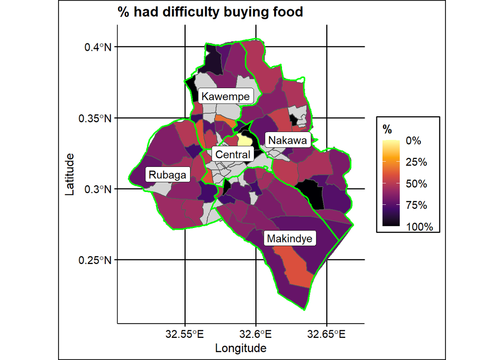

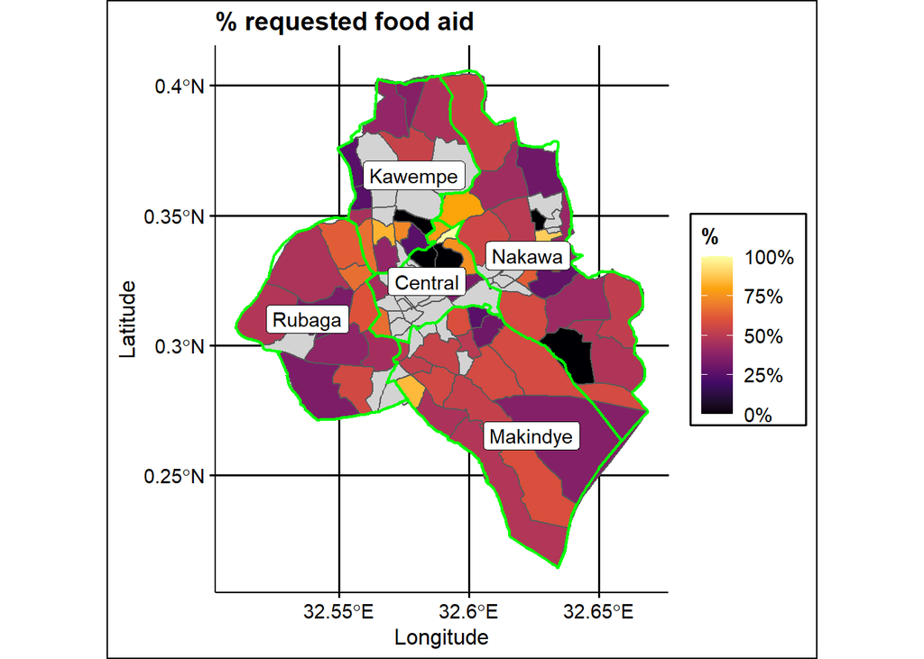

### Definitions of measures

Data definitions

| Measure | Definition |
| --- | --- |
| Asked for help from family or friends | Over the last 7 days (week), how often has your household asked for help from relatives or friends? |
| Eaten less than usual per day than normal | Over the last 7 days (week), how often has your household eaten less than usual per day than normal for this time of year? |
| Received help from family or friends | Over the last 7 days (week), how often has your household received help from relatives or friends? |
| Spent the whole day without eating | Over the last 7 days (week), how often has your household spent the whole day without eating? |
| Difficulties buying food | In the past 7 days, have you or any household member experienced difficulties in buying food? |
| Due to mobility restrictions | In the past 7 days, have you or any household member experienced difficulties in buying food due to mobility restrictions imposed by government? |
| Due to markets closed | In the past 7 days, have you or any household member experienced difficulties in buying food due to food markets being closed? |
| Due to shortages in martkets | In the past 7 days, have you or any household member experienced difficulties in buying food because of shortages in the markets I buy from? |
| Due to high price | In the past 7 days, have you or any household member experienced difficulties in buying food because of the price of the food was too high? |
| Due to low income | In the past 7 days, have you or any household member experienced difficulties in buying food because the household income has dropped? |
| Other (e.g. unemployed, shops closed) | In the past 7 days, have you or any household member experienced difficulties in buying food because the household income has dropped? Other |

## Identifying Covid Symptoms

### Aggregates

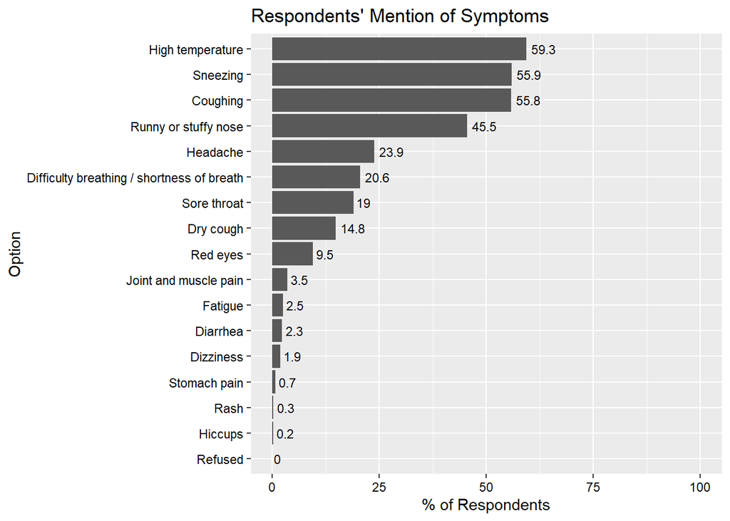

### Current averages

Mean responses in each Group (most recent date)

| Group | Date | Covid symptom: bleeding | Covid symptom: bruising | Covid symptom: chest pain | Covid symptom: chills | Covid symptom: cough | Covid symptom: diarrhea | Covid symptom: difficult breath | Covid symptom: dizzy | Covid symptom: dry cough | Covid symptom: fatigue | Covid symptom: headache | Covid symptom: hiccups | Covid symptom: high temperature | Covid symptom: joint pain | Covid symptom: rash | Covid symptom: red eyes | Covid symptom: run nose | Covid symptom: sneezing | Covid symptom: sore throat | Covid symptom: stomach pain | Covid symptom: weight loss | Covid symptom: weight loss | Covid symptom: weight loss | Covid symptom: taste loss | Covid symptom: toes lesions | Covid symptom: weakness | Covid symptom: weight loss |
| --- | --- | --- | --- | --- | --- | --- | --- | --- | --- | --- | --- | --- | --- | --- | --- | --- | --- | --- | --- | --- | --- | --- | --- | --- | --- | --- | --- | --- |
| Kampala | 2020-07-19 | 0.01 | 0 | 0.03 | 0.13 | 0.56 | 0.02 | 0.21 | 0.02 | 0.15 | 0.02 | 0.24 | 0 | 0.59 | 0.04 | 0 | 0.1 | 0.46 | 0.56 | 0.19 | 0.01 | 0 | 0.04 | 0 | 0.02 | 0 | 0.17 | 0.01 |

### Definitions of measures

Data definitions

| Measure | Definition |
| --- | --- |
| Covid symptom: bleeding | Mentioned bleeding as a symptom of Covid-19 |
| Covid symptom: bruising | Mentioned bruising as a symptom of Covid-19 |
| Covid symptom: chest pain | Mentioned chest pain as a symptom of Covid ovid-19 |
| Covid symptom: chills | Mentioned chills as a symptom of Covid-19 |
| Covid symptom: cough | Mentioned cough as a symptom of Covid-19 |
| Covid symptom: diarrhea | Mentioned diarrhea as a symptom of Covid-19 |
| Covid symptom: difficult breath | Mentioned difficult breath as a symptom of Covid ovid-19 |
| Covid symptom: dizzy | Mentioned dizzy as a symptom of Covid-19 |
| Covid symptom: dry cough | Mentioned dry cough as a symptom of Covid ovid-19 |
| Covid symptom: fatigue | Mentioned fatigue as a symptom of Covid-19 |
| Covid symptom: headache | Mentioned headache as a symptom of Covid-19 |
| Covid symptom: hiccups | Mentioned hiccups as a symptom of Covid-19 |
| Covid symptom: high temperature | Mentioned high temperature as a symptom of Covid-19 |
| Covid symptom: joint pain | Mentioned joint pain as a symptom of Covid-19 |
| Covid symptom: rash | Mentioned rash as a symptom of Covid-19 |
| Covid symptom: red eyes | Mentioned red eyes as a symptom of Covid ovid-19 |
| Covid symptom: run nose | Mentioned run nose as a symptom of Covid ovid-19 |
| Covid symptom: sneezing | Mentioned sneezing as a symptom of Covid-19 |
| Covid symptom: sore throat | Mentioned sore throat as a symptom of Covid-19 |
| Covid symptom: stomach pain | Mentioned stomach pain as a symptom of Covid-19 |
| Covid symptom: weight loss | Refused |
| Covid symptom: weight loss | Other |
| Covid symptom: weight loss | Don’t know |
| Covid symptom: taste loss | Mentioned taste loss as a symptom of Covid ovid-19 |
| Covid symptom: toes lesions | Mentioned toe lesions as a symptom of Covid ovid-19 |
| Covid symptom: weakness | Mentioned weakness as a symptom of Covid-19 |
| Covid symptom: weight loss | Mentioned weight loss as a symptom of Covid ovid-19 |

## Risk perception

### Aggregates

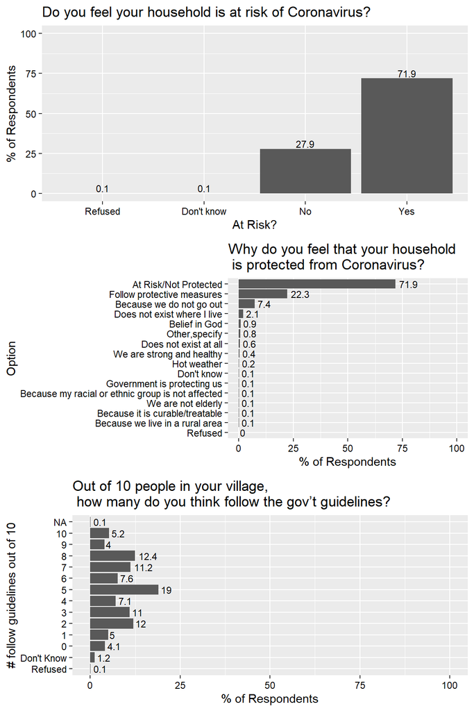

### Current averages

Mean responses in each Group (most recent date)

| Group | Date | Feel someone in household at risk of Covid | Home is protected from Covid because belief in God | Home is protected from Covid because we don’t go out | Home protected from Covid because we are in a rural area | Home is protected from Covid because it is curable | Home is protected from Covid because of prevention | Home protected from Covid because it doesn’t exist where I live | Home is protected from Covid because it doesn’t exist at all | Home is protected from Covid because we’re strong | Home is protected from Covid because we aren’t elderly | Home is protected from Covid because of hot weather | Home protected because my ethnic group isn’t affected | Home is protected from Covid gov is protecting us | Other,specify | Don’t know | Refused | Feel household is protected from Covid | Perception of people in the village following guidelines |
| --- | --- | --- | --- | --- | --- | --- | --- | --- | --- | --- | --- | --- | --- | --- | --- | --- | --- | --- | --- |
| Kampala | 2020-07-19 | 2.89 | 0.03 | 0.27 | 0 | 0 | 0.8 | 0.07 | 0.02 | 0.01 | 0 | 0.01 | 0 | 0 | 0.03 | 0 | 0 | NA | 16.87 |

### Maps

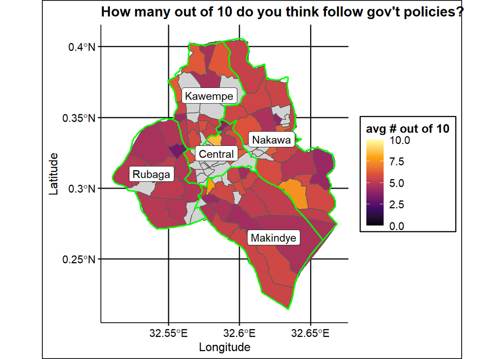

### Definitions of measures

Data definitions

| Measure | Definition |
| --- | --- |
| Feel someone in household at risk of Covid | Do you feel that you or anyone in your household is at risk of contracting COVID-19? |
| Home is protected from Covid because belief in God | Why do you feel that your household is protected from Covid-19? Belief in god |
| Home is protected from Covid because we don’t go out | Why we you feel that your household is protected from Covid-19? We don’t go out |
| Home protected from Covid because we are in a rural area | Why we you feel that your household is protected from Covid-19? We live in a rural area |
| Home is protected from Covid because it is curable | Why it you feel that your household le protected from Covid-19? It is curable |
| Home is protected from Covid because of prevention | Why do you feel that your household is protected from Covid-19? Follow preventive measures |
| Home protected from Covid because it doesn’t exist where I live | Why do you feel that your household is protected from Covid-19? Does not exist where I live |
| Home is protected from Covid because it doesn’t exist at all | Why do you feel that your household is protected from Covid-19? Does not exist at all |
| Home is protected from Covid because we’re strong | Why we you feel that your household is protected from Covid-19? We are strong |
| Home is protected from Covid because we aren’t elderly | Why we you feel that your household is protected from Covid-19? We are not elderly |
| Home is protected from Covid because of hot weather | Why we you feel that your household is protected from Covid-19? Hot weather |
| Home protected because my ethnic group isn’t affected | Why my you feel that your household ro protected from Covid-19? My ethnic group is not affected |
| Home is protected from Covid gov is protecting us | Why go you feel that your household ec protected from Covid-19? Gov is protecting us |
| Other,specify | Other,specify |
| Don’t know | Don’t know |
| Refused | Refused |
| Feel household is protected from Covid | Do you feel that their household is protected from COVID-19? |
| Perception of people in the village following guidelines | Out of 10 people in your village, how many do you think followed the government’s guidelines limiting social gatherings and movement in public? |

## Actions when suspecting infection

### Aggregates

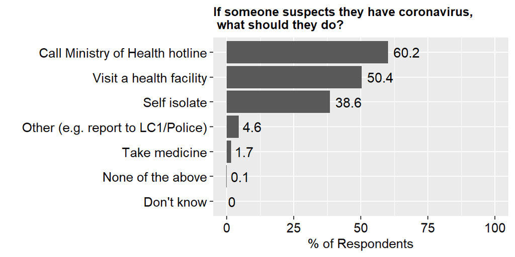

### Current averages

Mean responses in each Group (most recent date)

| Group | Date | Call Ministry of Health hotline | Visit a health facility | Take medicine | Self isolate | None of the above | Other specify | Don’t know | Refused |
| --- | --- | --- | --- | --- | --- | --- | --- | --- | --- |
| Kampala | 2020-07-19 | 0.6 | 0.5 | 0.02 | 0.39 | 0 | 0.05 | 0 | 0 |

### Definitions of measures

Data definitions

| Measure | Definition |
| --- | --- |
| Call Ministry of Health hotline | If someone suspects they have coronavirus, what should they do? Call Ministry of Health hotline |
| Visit a health facility | If someone suspects they have coronavirus, what should they do? Visit a health facility |
| Take medicine | If someone suspects they have coronavirus, what should they do? Take medicine |
| Self isolate | If someone suspects they have coronavirus, what should they do? Self isolate |
| None of the above | If someone suspects they have coronavirus, what should they do? None of the above |
| Other specify | If someone suspects they have coronavirus, what should they do? Other specify |
| Don’t know | If someone suspects they have coronavirus, what should they do? Don’t know |
| Refused | If someone suspects they have coronavirus, what should they do? Refused |

## Sources of information

### Aggregates

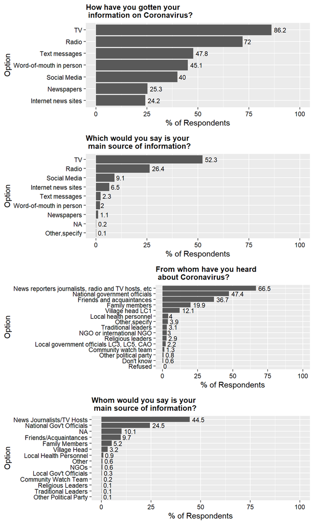

### Current averages

Mean responses in each Group (most recent date)

| Group | Date | Got info about Covid from Newspaper | Got info about Covid from Radio | Got info about Covid from TV | Got info about Covid from Internet news | Got info about Covid from Social Media | Got info about Covid from Word-of-Mouth | Got info about Covid from text messages | Got info about Covid from friends | Got info about Covid from traditional leaders | Got info about Covid from religious leaders | Got info about Covid from community watch team | Got info about Covid from family | Got info about Covid from health workers | Got info about Covid from news reporters | Got info about Covid from government officials | Got info about Covid from local government officials | Got info about Covid from village head | Got info about Covid from other political party | Got info about Covid from NGO | Trust the info about the coronavirus from Chairperson | Trust info about the coronavirus from news media | Trust about the coronavirus from MOH | Trust info about the coronavirus from the president | Trust info about the coronavirus from WHO | Other,specify | Don’t know | Refused | Main source | … |
| --- | --- | --- | --- | --- | --- | --- | --- | --- | --- | --- | --- | --- | --- | --- | --- | --- | --- | --- | --- | --- | --- | --- | --- | --- | --- | --- | --- | --- | --- | --- |
| Kampala | 2020-07-19 | 0.25 | 0.72 | 0.86 | 0.24 | 0.4 | 0.45 | 0.48 | 0.37 | 0.03 | 0.03 | 0.01 | 0.2 | 0.04 | 0.66 | 0.47 | 0.02 | 0.12 | 0.01 | 0.03 | 5.67 | 3.74 | 5.53 | 5.64 | 12.75 | 0.04 | 0.01 | 0 | NA | … |

### Definitions of measures

Data definitions

| Measure | Definition |
| --- | --- |
| Got info about Covid from Newspaper | How have you gotten your information on the Coronavirus? Newspaper |
| Got info about Covid from Radio | How have you gotten your information on the Coronavirus? Radio |
| Got info about Covid from TV | How have you gotten your information on the Coronavirus? TV |
| Got info about Covid from Internet news | How have you gotten your information on the Coronavirus? Internet news |
| Got info about Covid from Social Media | How have you gotten your information on the Coronavirus? Social media |
| Got info about Covid from Word-of-Mouth | How have you gotten your information on the Coronavirus? Word-of-mouth |
| Got info about Covid from text messages | How have you gotten your information on the Coronavirus? Text messages |
| Got info about Covid from friends | From whom have you heard or read information about the new Coronavirus? Friends and acquaintances |
| Got info about Covid from traditional leaders | From whom have you heard or read information about the new Coronavirus? Traditional leaders |
| Got info about Covid from religious leaders | From whom have you heard or read information about the new Coronavirus? Religious leaders |
| Got info about Covid from community watch team | From whom have you heard or read information about the new Coronavirus? Community watch team |
| Got info about Covid from family | From whom have you heard or read information about the new Coronavirus? Family members |
| Got info about Covid from health workers | From whom have you heard or read information about the new Coronavirus? Local health personnel |
| Got info about Covid from news reporters | From whom have you heard or read information about the new Coronavirus? News reporters (journalists, radio and TV hosts, etc) |
| Got info about Covid from government officials | From whom have you heard or read information about the new Coronavirus? National government officials |
| Got info about Covid from local government officials | From whom have you heard or read information about the new Coronavirus? Local government officials (LC3, LC5, CAO) |
| Got info about Covid from village head | From whom have you heard or read information about the new Coronavirus? Village head (LC1) |
| Got info about Covid from other political party | From whom have you heard or read information about the new Coronavirus? Other political party |
| Got info about Covid from NGO | From whom have you heard or read information about the new Coronavirus? NGO |
| Trust the info about the coronavirus from Chairperson | How much do you trust the information about the coronavirus coming from the following sources? LC1 chairperson |
| Trust info about the coronavirus from news media | How much do you trust the information about the coronavirus coming from the following sources? News media (newspapers, radio, television) |
| Trust about the coronavirus from MOH | How much do you trust the information about the coronavirus coming from the following sources? The Ministry of Health |
| Trust info about the coronavirus from the president | How much do you trust the information about the coronavirus coming from the following sources? The President |
| Trust info about the coronavirus from WHO | How much do you trust the information about the coronavirus coming from the following sources? World Health Organization |
| Other,specify | Other,specify |
| Don’t know | Don’t know |
| Refused | Refused |
| Main source | Which of the ones you just mentioned would you say is the main source of information? |
| Main source | Main |
| All sources | How have you gotten your information on the Coronavirus? |
| Main source | Main |

## Preventive measures

### Aggregates

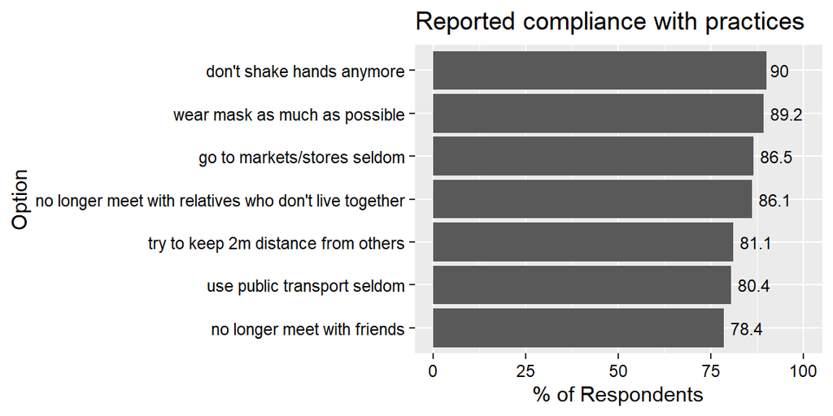

### Current averages

Mean responses in each Group (most recent date)

| Group | Date | Wear mask | Not shakehand | Social distancing | Avoid going to market | Avoid meeting friends | Avoid meeting relatives | Avoid public transportation |
| --- | --- | --- | --- | --- | --- | --- | --- | --- |
| Kampala | 2020-07-19 | 0.89 | 0.9 | 0.81 | 0.87 | 0.78 | 0.86 | 0.8 |

### Maps

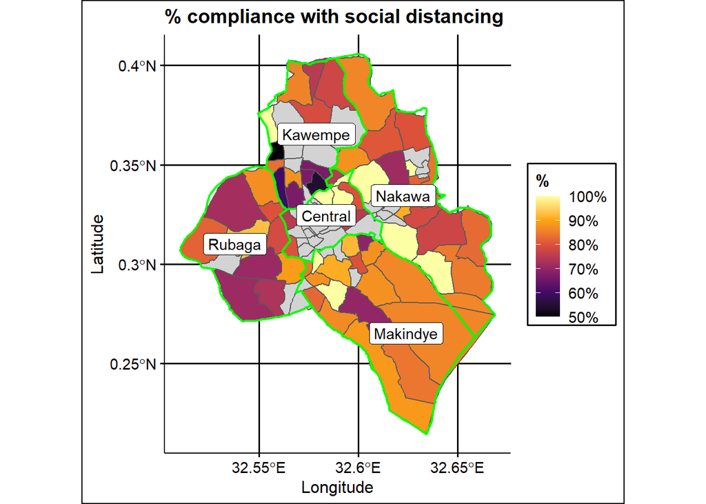

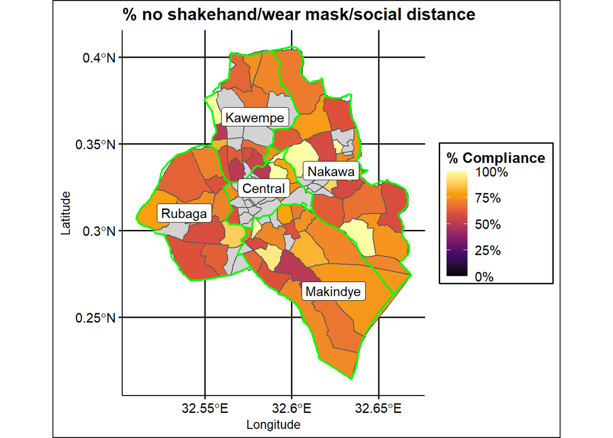

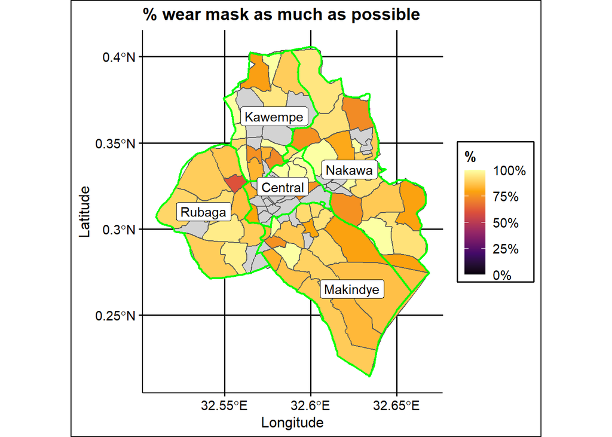

### Definitions of measures

Data definitions

| Measure | Definition |
| --- | --- |
| Wear mask | I wear a mask as much as possible when outside my home |
| Not shakehand | I don’t shake hands anymore |
| Social distancing | I try to keep a distance of at least 2 meters from people outside my household |
| Avoid going to market | I go to markets and stores as seldom as possible |
| Avoid meeting friends | I no longer meet with friends |
| Avoid meeting relatives | I no longer meet with relatives who do not live with me |
| Avoid public transportation | I use public transport as seldom as possible |

## All Data

### Browse data

[output not shown]

[output cut: 1715 more lines]

### Data summaries

**Technical**: Summary measures on all data.

| variable | Kampala | Overall |
| --- | --- | --- |
| N | 1725 | 1725 |
| Effectiveness of wearing a mask | 12.9426 | 12.9426 |
| Government truthful or untruthful? | 15.7043 | 15.7043 |
| Government information truthful or untruthful? | 15.9646 | 15.9646 |
| Distribution of aid well or poorly done? | 8.56 | 8.56 |
| Performance of Ministry of Health | 6.8452 | 6.8452 |
| Performance of President | 12.7246 | 12.7246 |
| Performance of LC1 Chairperson | 52.3426 | 52.3426 |
| Agree with mandatory mask? | 2.0887 | 2.0887 |
| Felt that everything was an effort | 2.3919 | 2.3919 |

[output cut: 133 more lines]

Notes